# matplotlib的基本用法 （3）

```python
import matplotlib.pyplot as plt
import numpy as np
plt.rcParams['font.sans-serif']=['KaiTi']  #中文字体
plt.rcParams['axes.unicode_minus']=False   #负号显示的问题
```

```
Matplotlib is building the font cache; this may take a moment.
```

## 1. 其他常见图形

### 1.1 饼图

定义：Axes.pie(self, x, explode=None, labels=None, colors=None, autopct=None, pctdistance=0.6, shadow=False, labeldistance=1.1, startangle=None, radius=None, counterclock=True, wedgeprops=None, textprops=None, center=(0, 0), frame=False, rotatelabels=False, *, data=None)

地址：https://matplotlib.org/stable/api/_as_gen/matplotlib.axes.Axes.pie.html

案例，2019年4个季度的全国GDP

```python
qname=['第一季度','第二季度','第三季度','第四季度']
qgdp=np.array([278019.7,252208.7,242573.8,218062.8])
```

[output not shown]

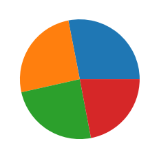

```python
fig_pie,ax_pie=plt.subplots()
ax_pie.pie(qgdp)
```

#### 加上名称标签

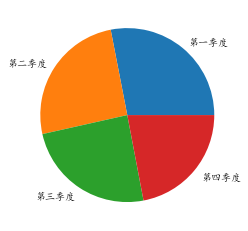

```python
ax_pie.cla() #清空子图
ax_pie.pie(qgdp,labels=qname)
fig_pie
```

饼状图用于展示每一个数据占总体样本的比值

#### 加上数字标签

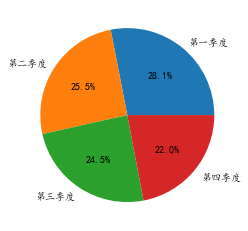

```python
ax_pie.cla()
ax_pie.pie(qgdp,labels=qname,autopct = '%.1f%%') ##%.1f表示保留一位小数，%%表示后边加上百分号
fig_pie
```

可以发现，第一季度GDP贡献最大，第四季度最小。

原因可能是过年消费对GDP的拉动作用很大。

```python
qgdp_2020=np.array([296297.8,264976.3,248985.1,205727.0])
#有疫情的2020年的季度GDP
#数据来源：https://data.stats.gov.cn/easyquery.htm?cn=B01
```

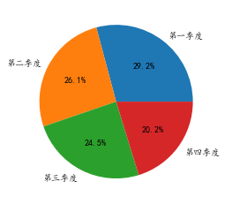

```python
ax_pie.cla()
ax_pie.pie(qgdp_2020,labels=qname,autopct = '%.1f%%') ##%.1f表示保留一位小数，%%表示后边加上百分号
fig_pie
```

#### 添加分离特效

```python
explode = [0.2, 0, 0, 0]  # 定义每个饼分离的距离
```

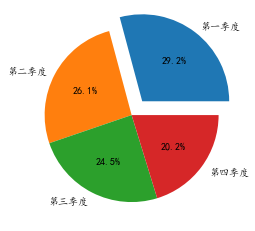

```python
ax_pie.cla()
ax_pie.pie(qgdp_2020,labels=qname,autopct = '%.1f%%',explode=explode) #加上explode参数
fig_pie
```

```python
#当数据个数较多时，可以使用此方法
explode=np.zeros(qgdp_2020.size)
explode[1]=0.3
```

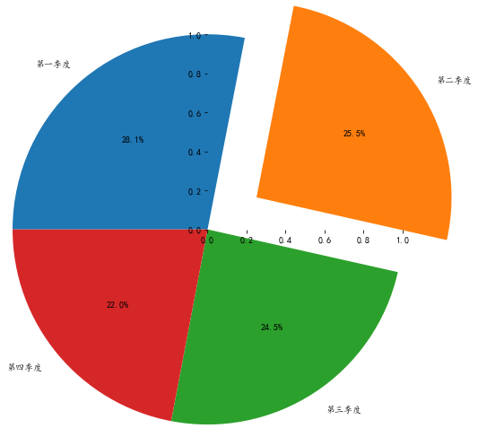

```python
ax_pie.cla()
ax_pie.pie(qgdp,labels=qname,autopct = '%.1f%%',explode=explode,startangle=180,radius=1,counterclock=False,frame=True) #加上explode参数
fig_pie
```

### 1.2 箱线图

定义：Axes.boxplot(self, x, notch=None, sym=None, vert=None, whis=None, positions=None, widths=None, patch_artist=None, bootstrap=None, usermedians=None, conf_intervals=None, meanline=None, showmeans=None, showcaps=None, showbox=None, showfliers=None, boxprops=None, labels=None, flierprops=None, medianprops=None, meanprops=None, capprops=None, whiskerprops=None, manage_ticks=True, autorange=False, zorder=None, *, data=None)[source]¶ 地址：https://matplotlib.org/stable/api/_as_gen/matplotlib.axes.Axes.boxplot.html

案例：中国2018年各省的电力消费量数据（单位：亿度电） 来源：国家统计局

```python
# 数据的dictionary
power_consumption={'北京市':1142.38,'天津市':861.44,'河北省':3665.66,'山西省':2160.53,'内蒙古':3353.44,'辽宁省':2302.38,'吉林省':750.57,'黑龙江省':973.88,'上海市':1566.66,'江苏省':6128.27,'浙江省':4532.82,'安徽省':2135.07,'福建省':2313.82,'江西省':1428.77,'山东省':5916.77,'河南省':3417.68,'湖北省':2071.43,'湖南省':1745.24,'广东省':6323.35,'广西':1702.75,'海南省':326.78,'重庆市':1114.47,'四川省':2459.49,'贵州省':1482.12,'云南省':1679.08,'西藏':69.02,'陕西省':1594.17,'甘肃省':1289.52,'青海省':738.34,'宁夏':1064.85,'新疆':2138.33}
```

```python
power_consumption
```

```
{'北京市': 1142.38,
 '天津市': 861.44,
 '河北省': 3665.66,
 '山西省': 2160.53,
 '内蒙古': 3353.44,
 '辽宁省': 2302.38,
 '吉林省': 750.57,
 '黑龙江省': 973.88,
 '上海市': 1566.66,
 '江苏省': 6128.27,
 '浙江省': 4532.82,
 '安徽省': 2135.07,
 '福建省': 2313.82,
 '江西省': 1428.77,
 '山东省': 5916.77,
 '河南省': 3417.68,
 '湖北省': 2071.43,
 '湖南省': 1745.24,
 '广东省': 6323.35,
 '广西': 1702.75,
 '海南省': 326.78,
 '重庆市': 1114.47,
 '四川省': 2459.49,
 '贵州省': 1482.12,
 '云南省': 1679.08,
 '西藏': 69.02,
 '陕西省': 1594.17,
 '甘肃省': 1289.52,
 '青海省': 738.34,
 '宁夏': 1064.85,
 '新疆': 2138.33}
```

[output not shown]

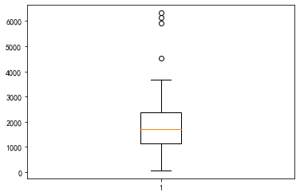

```python
fig_box,ax_box=plt.subplots()
ax_box.boxplot(power_consumption.values())
```

#### 多组对比，箱线图主要的功能是比较多类样本的分布差异

我们把31个省分为南方和北方，其中北方省份为：山东 河南 山西 陕西 甘肃 青海 新疆 河北 天津 北京 内蒙古 辽宁 吉林 黑龙江 宁夏

```python
north_power_consumption={'北京市': 1142.38, '天津市': 861.44, '河北省': 3665.66, '山西省': 2160.53, '内蒙古自治区': 3353.44, '辽宁省': 2302.38, '吉林省': 750.57, '黑龙江省': 973.88, '山东省': 5916.77, '河南省': 3417.68, '陕西省': 1594.17, '甘肃省': 1289.52, '青海省': 738.34, '宁夏回族自治区': 1064.85, '新疆维吾尔自治区': 2138.33}
south_power_consumption={ '上海市': 1566.66, '江苏省': 6128.27, '浙江省': 4532.82,'安徽省': 2135.07, '福建省': 2313.82, '江西省': 1428.77, '湖北省': 2071.43,'湖南省': 1745.24, '广东省': 6323.35, '广西壮族自治区': 1702.75, '海南省': 326.78, '重庆市': 1114.47,'四川省': 2459.49, '贵州省': 1482.12, '西藏自治区': 69.02, '云南省': 1679.08}
```

```python
combine_data=[list(north_power_consumption.values()),list(south_power_consumption.values())]
print(combine_data)
```

```
[[1142.38, 861.44, 3665.66, 2160.53, 3353.44, 2302.38, 750.57, 973.88, 5916.77, 3417.68, 1594.17, 1289.52, 738.34, 1064.85, 2138.33], [1566.66, 6128.27, 4532.82, 2135.07, 2313.82, 1428.77, 2071.43, 1745.24, 6323.35, 1702.75, 326.78, 1114.47, 2459.49, 1482.12, 69.02, 1679.08]]
```

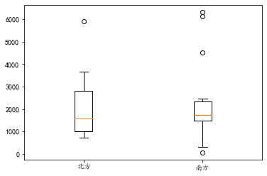

```python
ax_box.cla()
ax_box.boxplot(combine_data,labels=['北方','南方'])
fig_box
```

通过图形可以看出，南北方各省用电量的均值差别不大，但分布上北方更离散一些。

（如以用电量作为省份经济发展情况的指标，可以认为南方的贫富差距更小一些）

### 1.3 多个子图

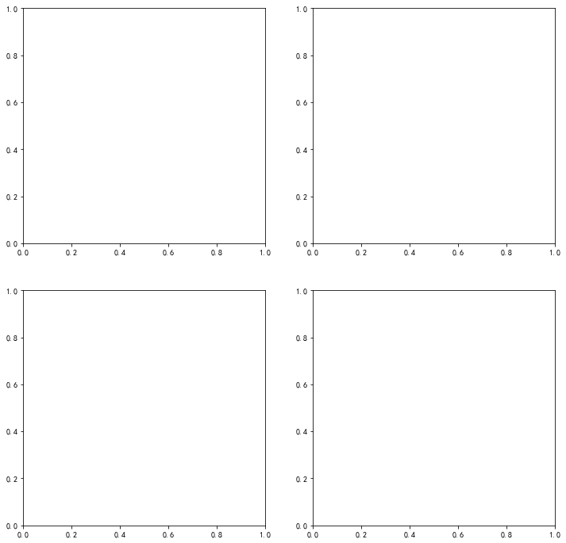

```python
fig_subplots,ax_subplots=plt.subplots(2,2,figsize=[12,12])
```

```python
ax_subplots #多个子图的话，就是一个数组，元素是对应位置的子图。对于每一个子图的操作，与之前的没有区别。
```

[output not shown]

```python
ax_subplots.size
```

```
4
```

```python
ax_subplots.shape
```

```
(2, 2)
```

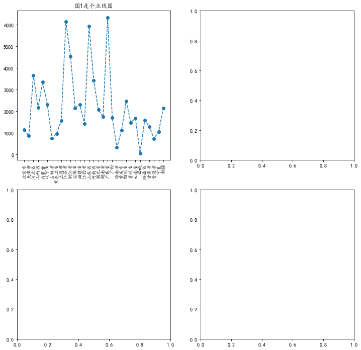

```python
ax_subplots[0,0].cla()
x,y=list(power_consumption.keys()),list(power_consumption.values())
ax_subplots[0,0].plot(x,y,'--o')
ax_subplots[0,0].set_xticklabels(x, rotation=90 )
ax_subplots[0,0].set_title('图1是个点线图')
fig_subplots
```

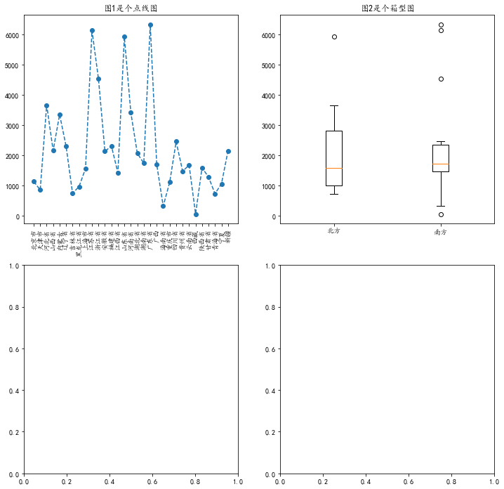

```python
ax_subplots[0,1].cla()
ax_subplots[0,1].boxplot(combine_data,labels=['北方','南方'])
ax_subplots[0,1].set_title('图2是个箱型图')
fig_subplots
```

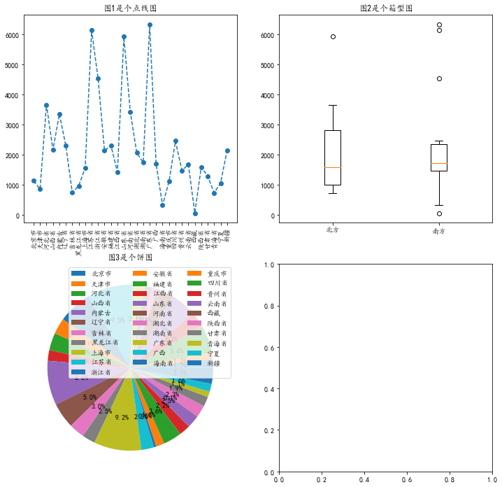

```python
ax_subplots[1,0].cla()
ax_subplots[1,0].pie(y,autopct = '%.1f%%')
ax_subplots[1,0].legend(labels=x,ncol=3)
ax_subplots[1,0].set_title('图3是个饼图')
fig_subplots
```

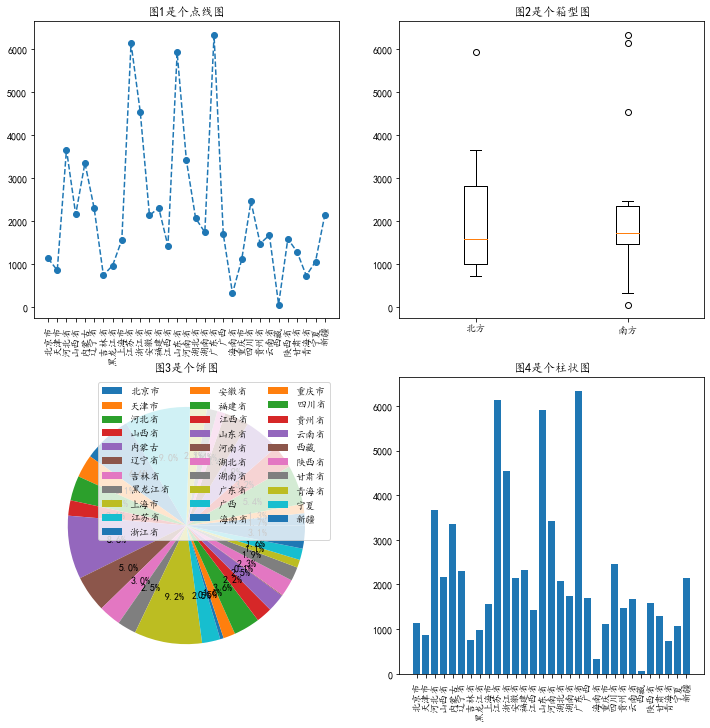

```python
ax_subplots[1,1].cla()
ax_subplots[1,1].bar(x,y)
ax_subplots[1,1].set_xticklabels(x, rotation=90 )
ax_subplots[1,1].set_title('图4是个柱状图')
fig_subplots
```

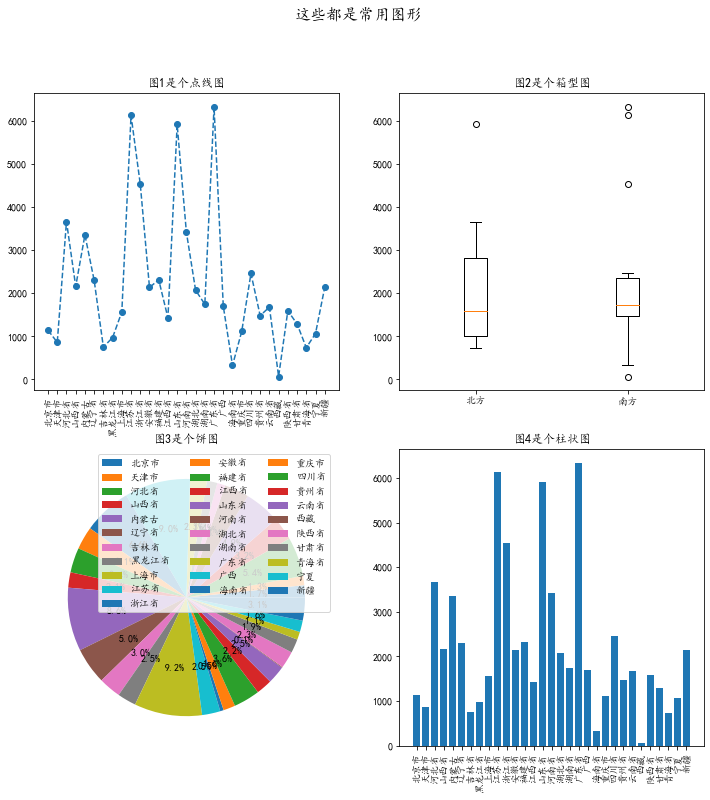

```python
fig_subplots.suptitle('这些都是常用图形', fontsize=16) #Figure对象要设置总标题，可以用supitle命令,super title
fig_subplots.savefig('常用图形.pdf')
fig_subplots
```

## 2.词云

### 2.1 简介

文字云是关键词的视觉化描述，用于汇总用户生成的标签或一个网站的文字内容。(参考：https://zh.wikipedia.org/wiki/标签云)

**例如下图是Trump 2011-2015年发的推特内容的词云图**

[figure not shown]

来源文献:Allen, David & McAleer, Michael. (2018). President Trump Tweets Supreme Leader Kim Jong-Un on Nuclear Weapons: A Comparison with Climate Change †. Sustainability. 10. 2310. 10.3390/su10072310.

**再例如下图是双十一狂欢夜全网词云图**

[figure not shown]

### 2.2 安装使用

使用的包：word_cloud 官方包地址：https://github.com/amueller/word_cloud 安装方式：命令行使用pip或conda（仅anaconda环境的同学）进行安装

```
pip install wordcloud
```

或

```
conda install -c conda-forge wordcloud
```

### 2.3 操作实例

十三五五年政府工作报告（17-21）

```python
from wordcloud import WordCloud  #注意，大小写是要严格区分的
```

```python
type(open('17工作报告.txt'))
```

```
_io.TextIOWrapper
```

```python
#python用open（‘文件名’）的命令来打开一个文件，并返回一个文件类
#一个文件类的.read()属性可以返回这个文件的所有文字(字符串)
text17=open('17工作报告.txt',encoding='utf-8').read()   #注意编码，中文一般需要把编码改成utf-8
type(text17)
```

```
str
```

```python
text18=open('18工作报告.txt',encoding='utf-8').read()
text19=open('19工作报告.txt',encoding='utf-8').read()
text20=open('20工作报告.txt',encoding='utf-8').read()
text21=open('21工作报告.txt',encoding='utf-8').read()
```

```python
text_total=text17+text18+text19+text20+text21
```

text_total是17、18、19、20、21五年的政府工作报告组成的字符串

```python
#词云默认的字体不支持中文，需要自己设置一个中文字体，非Windows系统需要自己找一个中文字体的路径替换
font = 'C:\Windows\Fonts\simhei.ttf'
wc=WordCloud(font_path=font,background_color='white').generate(text17)  #将导入的文字生成词云
```

```python
type(wc) #生成的是一个词云对象,可以认为实际上就是一个位图图片，不是矢量图
```

```
wordcloud.wordcloud.WordCloud
```

```
(-0.5, 399.5, 199.5, -0.5)
```

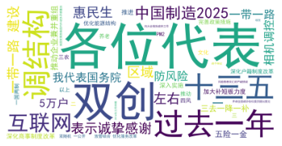

```python
plt.imshow(wc)
plt.axis(False)
```

```python
wc.to_file('wc.jpg')  #这个图片可以使用to_file函数保存到文件
```

```
<wordcloud.wordcloud.WordCloud at 0x20814408e50>
```

### 2.4 根据词云做数据分析

比较17，18，19三年的工作报告有何异同

```python
wc17=WordCloud(font_path=font,background_color="white").generate(text17)
wc18=WordCloud(font_path=font,background_color="white").generate(text18)
wc19=WordCloud(font_path=font,background_color="white").generate(text19)
wc20=WordCloud(font_path=font,background_color="white").generate(text20)
wc21=WordCloud(font_path=font,background_color="white").generate(text21)
```

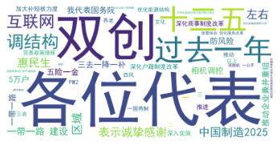

```python
plt.axis(False)
plt.imshow(wc17)
```

17年的关键词有：各位代表，过去一年，双创，互联网，调结构，十三五

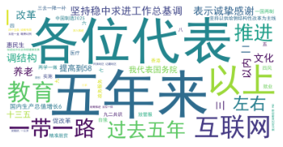

```python
plt.axis(False)
plt.imshow(wc18)
```

18年的关键词有：五年来，各位代表，互联网，以上，教育，过去五年，一带一路

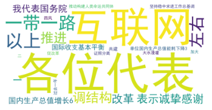

```python
plt.axis(False)
plt.imshow(wc19)
```

19年的关键词有：各位代表，互联网，一带一路，调结构，左右，推进，以上，改革

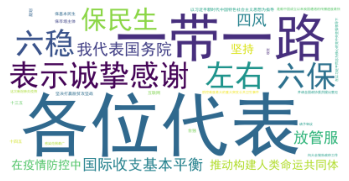

```python
plt.axis(False)
plt.imshow(wc20)
```

20年的关键词有：各位代表，一带一路，六保，保民生，放管服

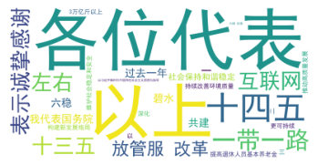

```python
plt.axis(False)
plt.imshow(wc21)
```

21年的关键词有：各位代表，十四五，十三五，一带一路

（因为18年换届，总理需要对上一个5年任期进行总结，所以出现了“五年”这一关键词）

但是，像各位代表、左右、以上这些词是用来连接语句的，每年都有，出现频率很高但分析价值不大，因此最好可以在做词云图时剔除

### 2.5 通过设置停用语stopwords来人工剔除一些意义不大的词语

需要使用wordcloud包中的STOPWORDS功能

```python
# 设置停用语，即人工排除掉一些意义不大的词语
from wordcloud import STOPWORDS
stopwords = set(STOPWORDS)
stopwords.add("各位代表")
stopwords.add("以上")
stopwords.add("左右")
stopwords.add("推进")
stopwords.add("五年来")
```

```python
print(stopwords)
```

```
{'by', 'should', 'your', 'hers', 'its', 'all', "couldn't", 'just', 'off', "you've", 'out', 'about', 'those', 'herself', 'than', 'can', 'would', 'for', "i'd", 'such', 'i', "he'd", "aren't", 'both', 'there', 'few', "doesn't", 'at', 'below', 'yourselves', 'is', "what's", "haven't", 'more', 'yourself', …
```

```python
wc_stopword=WordCloud(font_path=font,background_color="white",stopwords=stopwords).generate(text_total)
```

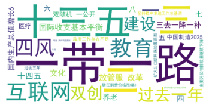

```python
plt.axis(False)
plt.imshow(wc_stopword)
```

我们可以发现：17~21五年工作报告中，一带一路、十三五、互联网是出现最多的，另外还有四风、双创、养老、教育等等

```python
wc_stopword.to_file("wc_stopword.jpg") #savefig不能用
```

```
<wordcloud.wordcloud.WordCloud at 0x2081458cf10>
```

### 2.6 创建特定形状的词云图

wordcloud这个包提供了一种叫做面具mask的方法 即通过设置一个背景图/显示区间

#### 2.6.1 首先导入图片文件，使用pillow包

```python
from PIL import Image
```

参考https://www.liaoxuefeng.com/wiki/1016959663602400/1017785454949568 PIL：Python Imaging Library，已经是Python平台事实上的图像处理标准库了，一群志愿者在之前PIL的基础上创建了兼容的版本，名字叫Pillow anaconda已包含，没有的可以通过`pip install pillow`安装

```python
guohui=Image.open('fig/国徽.jpg')
```

```python
type(guohui)
```

```
PIL.JpegImagePlugin.JpegImageFile
```

[figure not shown]

```python
plt.imshow(guohui)
```

#### 2.6.2 将图片转换成数组，因为wordcloud包实质上是根据每一个像素点位置的颜色深浅来判断这个像素点上是否要放上文字

```python
fig_mask = np.array(guohui)
```

```python
fig_mask.shape
```

```
(976, 900, 3)
```

```python
print(fig_mask[0,0]) #代表RGB颜色。
#需要注意的是，有的透明的png会有第四位代表透明度，这类透明的图片作为mask使用会有问题
```

```
[255 255 255]
```

#### 2.6.3 使用mask属性添加mask图形

```python
wc_mask=WordCloud(mask=fig_mask,font_path=font,background_color="white",stopwords=stopwords).generate(text_total)
```

```
(-0.5, 899.5, 975.5, -0.5)
```

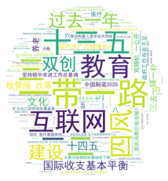

```python
plt.imshow(wc_mask)
plt.axis(False)
```

```python
wc_mask.to_file('guohui_wc.pdf') ##词云图不是矢量图，保存成pdf也是位图形式
```

```
<wordcloud.wordcloud.WordCloud at 0x20814b14640>
```

#### 2.6.4 给图形描个边，使用contour属性

```python
wc_mask_contour=WordCloud(contour_width=3,contour_color="steelblue",mask=fig_mask,font_path=font,background_color="white",stopwords=stopwords).generate(text_total)
```

```
(-0.5, 899.5, 975.5, -0.5)
```

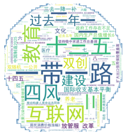

```python
plt.imshow(wc_mask_contour)
plt.axis(False)
```

```python
wc_mask_contour.to_file('guohui_wc_contour.jpg')
```

```
<wordcloud.wordcloud.WordCloud at 0x20814cfde80>
```

## 3.作业

**以《三国演义》文本为材料，绘制词云图。并给出一条分析结论。**

- 将本次所有作业内容在一个notebook里完成
- 保存为notebook格式（后缀名为.ipynb）
- 文件名为“作业2-姓名-学号”
- 将文件以附件的形式发送到教师邮箱 wangge@ncepu.edu.cn，邮件主题为“python-作业2-姓名”
- 作业时间，3月21日中午12：00前，以发送时间戳为准。过时不候。